# Comparative Study of Adversarial Generative Models on CIFAR-10: From Conditional WGANs to Self-Attention GANs

## Group Information

- **Group ID**: ADL Group 75
- **Group Members**:
  1. Ravindra Kumar Tholiya - 2023AA05124
  2. Shivam Sahil - 2023AA05663
  3. Jahnavi Gali - 2023AA05684
  4. Chakshu - 2023AA05280

## Summary of Observations - Task 1 cWGAN

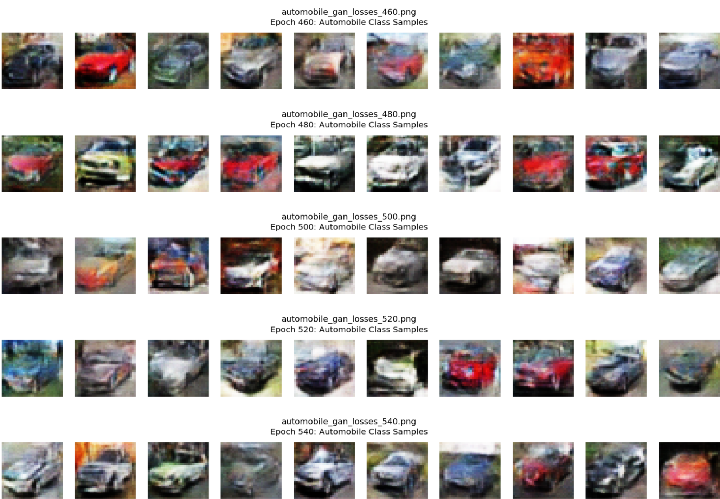

- Highest Inception Score (~3.6–3.7), but relatively high FID (~110–115).
- Interpretation: The generated images were diver enough that the classifier recognized multiple classes (yielding a higher IS),
- But they weren’t particularly close to real images in distribution (leading to the higher FID).

## Summary of Observations - Task 2 SNGAN

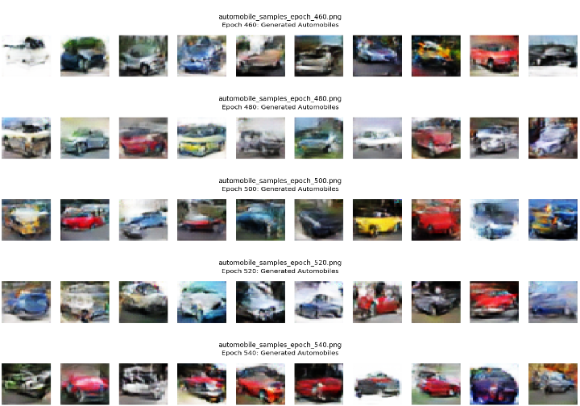

### Slightly lower Inception Score (IS) than cWGAN:

- Indicates somewhat less class diversity in the generated samples.
- The model may lean toward producing images from certain “modes” of the CIFAR-10 distribution more frequently.

### Significantly better Fréchet Inception Distance (FID) compared to cWGAN:

- Suggests the generated images are closer to the real data distribution overall.
- Visual inspection often shows more coherent structures, fewer artifacts, and better color consistency.

### Role of Spectral Normalization:

- Helps stabilize training by constraining the discriminator’s capacity, preventing it from overpowering the generator.
- Likely responsible for the smoother convergence and more realistic image details.

### Training Observations:

- The logs show steady, incremental improvements; no signs of severe mode collapse.
- Consistent generator and discriminator losses suggest balanced adversarial updates.

### Overall Takeaway:

- **SNGAN** trades off a bit of image diversity (hence a slightly lower IS) for more accurate alignment with real image features (manifested in the lower FID).
- Highlights how spectral normalization can improve visual fidelity while modestly restricting the range of generated variations.

## Summary of Observations - Task 3 SAGAN variant without spectral norm and TTUB

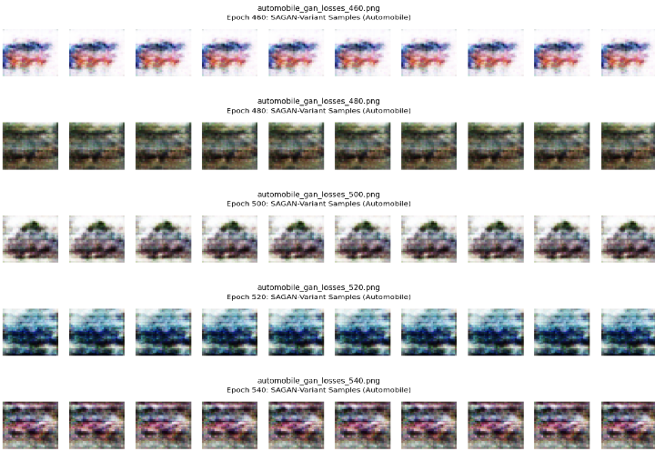

### Inception Score

**Inception Score** is quite low (1.7), indicating very limited diversity and poor generation quality.

- Many generated samples appear visually similar or fail to convincingly match any specific CIFAR-10 class.

**FID above 300** underscores significant divergence from the real data distribution.

- Images likely contain noticeable artifacts or structural inconsistencies.

### **Role of Removing Spectral Normalization**:

- Without spectral normalization, the discriminator can become overly strong or unstable, leading to erratic adversarial feedback.
- This often results in either mode collapse or chaotic generator outputs.

### **Self-Attention Alone Not Enough**:

- Although self-attention can capture long-range dependencies, stability mechanisms like spectral norm and TTUB are also crucial.
- Simply adding attention without these controls can exacerbate training instability.

### **Training Observations**:

- Large, unpredictable swings in generator and discriminator losses suggest severe training volatility.
- The model never fully converged to a stable solution despite extended epochs.

### **Overall Takeaway**:

- **Partial SAGAN** highlights that self-attention alone does not guarantee performance improvements.
- Proper regularization (spectral norm, TTUB) and balanced hyperparameters are essential for stable high-fidelity generation.

## Summary of Observations - Task 4 Full SAGAN with spectral norm + TTUB

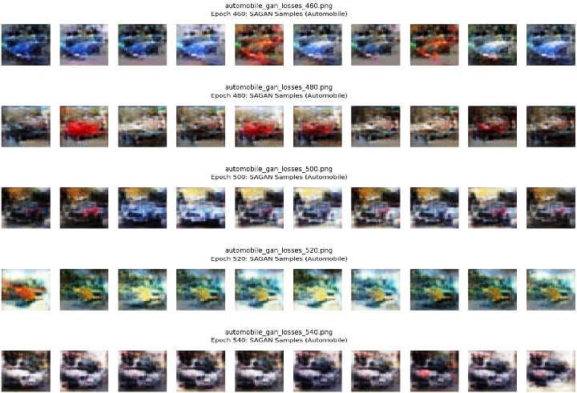

### **Inception Score**

##### **Inception Score** remains low (~1.6–1.7), despite reintroducing spectral normalization and TTUB.

##### Indicates the model is still failing to diversify or properly learn class characteristics in CIFAR-10.

### **High FID (300–360 range)**:

##### Generated images deviate significantly from the real data manifold, suggesting unresolved training instability or suboptimal hyperparameters.

### **Spectral Normalization + TTUB**:

##### These features are designed to stabilize the discriminator and improve gradient flow.

##### However, the poor results suggest other factors (e.g., learning rate, batch size, architecture details) may still be improperly tuned.

### **Self-Attention Implementation**:

##### While attention can improve global coherence, it is computationally more demanding and finicky to train.

##### If the rest of the pipeline (optimizer settings, initialization) is not carefully managed, improvements from attention may be canceled out by instability.

### **Training Observations**:

##### Logs show fluctuating losses, sometimes spiking generator losses followed by near-zero discriminator losses or vice versa.

##### The system never reaches the mode coverage or fidelity levels seen in simpler methods (cWGAN/SNGAN).

### **Overall Takeaway**:

##### **Full SAGAN** potentially has the highest capacity but is also the most sensitive to training hyperparameters and architecture details.

##### Achieving the expected performance requires a more rigorous hyperparameter search, perhaps an alternate training schedule, or additional regularizations.

## Training Behaviors & Instability

##### **Tasks 1 & 2** (cWGAN & SNGAN) both seemed moderately stable:

- - No glaring “Mode Collapse” issues or exploding gradients in the logs.
    - Incremental improvements to IS and FID over epochs, although cWGAN’s FID stayed relatively high.

##### **Tasks 3 & 4** (Both SAGAN variants) showed large generator losses, occasionally near-zero discriminator losses, or big swings:

  - - These are typical signatures of instability in adversarial training.
    - The final results confirm that the networks didn’t converge to a high-quality image distribution.
    - The attention mechanism plus or minus spectral normalization can be tricky to tune, and the resulting training was more erratic.

## Hyperparameters & Implementation Details

- While the cWGAN and SNGAN code/hyperparameters (batch size, learning rate schedules, etc.) seemed to stabilize training well enough for decent results, the SAGAN setups were likely more sensitive to parameter choices.
- For instance, SAGAN often requires more careful balancing of learning rates, an appropriate beta1/beta2 for Adam/AdamW, and possibly a tuned batch size. If any of these were off or inconsistent, it could severely degrade performance (as seems to have happened in Tasks 3 & 4).

## Key Takeaways

- **Conditional cWGAN** can excel in generating class-distinguishable images (good IS) but might struggle with matching the fine-grained distribution (hence higher FID).
  - **SNGAN** remains a strong baseline, especially for overall fidelity and stability. Spectral normalization is quite effective at keeping the discriminator from overpowering the generator.
  - **SAGAN** (with self-attention) *should* improve performance if carefully tuned — especially in capturing global features and finer details — but in this particular setup, it underperformed. That underperformance likely reflects an issue in hyperparameters, code implementation, or training strategy rather than the SAGAN architecture itself.
  - Even small code details or hyperparameter changes can drastically affect training stability in attention-based GANs. The big leaps in generator/discriminator losses in the logs highlight how quickly things can “break” if not carefully balanced.

### Enhancements

- Re-verification and optimisation of learning rate policies, weight initialization, and optimizer settings for SAGAN variants.
- Experiment with smaller steps of spectral norm or different attention-block placements.
- Increasing training epochs or adding other regularization to see if SAGAN performance can catch up.

### Conclusion

**cWGAN** gave us the strongest Inception Score, **SNGAN** gave us the best FID, and both SAGAN variants struggled significantly (likely due to hyperparameter or architectural issues).  
This highlights just how sensitive GAN training can be — especially once we add more sophisticated modules like self-attention.

```python
# Install necessary packages
!apt-get install texlive texlive-xetex texlive-latex-extra pandoc
!pip install pypandoc

# Mount Google Drive
from google.colab import drive
drive.mount("/content/drive", force_remount=True)

# Copy the notebook to the current directory
!cp 'drive/My Drive/Colab Notebooks/Assignment2_Group75_Task5.ipynb' ./

# Convert the notebook to PDF while keeping the code and output
!jupyter nbconvert --to html "Assignment2_Group75_Task5.ipynb"


# Download the generated PDF
from google.colab import files
files.download('Assignment2_Group75_Task5.html')
```